# Análisis de Votaciones — Diputados Argentina 2022–2026

Puntos ideales, distancias y redes de coincidencia

Lavia-Ram-Salazar-Stipisich

2026-10-23

## Motivación

- ¿Cómo se ubican los bloques en el eje ideológico entre 2022 y 2026?
- ¿Los bloques son cohesionados o hay fisuras internas?
- ¿La red de coincidencias de voto reproduce los bloques oficiales?
- ¿Quiénes son los “puentes” entre comunidades?

## Datos y metodología

**Fuentes** - `idps.csv`: punto ideal por legislador-año (`idp_pca`, `idp_bayes`, `sd_bayes`). - `legisladores_bloque_provincia.csv`: bloque y provincia. - `sesiones_dt.csv`: votaciones nominales (legislador × votación × voto).

**Métodos** - Estandarización del punto ideal por año. - Distancias euclídeas intra/inter bloque. - Coincidencia de votos vía índice de **Jaccard** (solo AFIRMATIVO/NEGATIVO). - Detección de comunidades con **Louvain**. - Centralidad: degree y betweenness.

## Puntos ideales por año

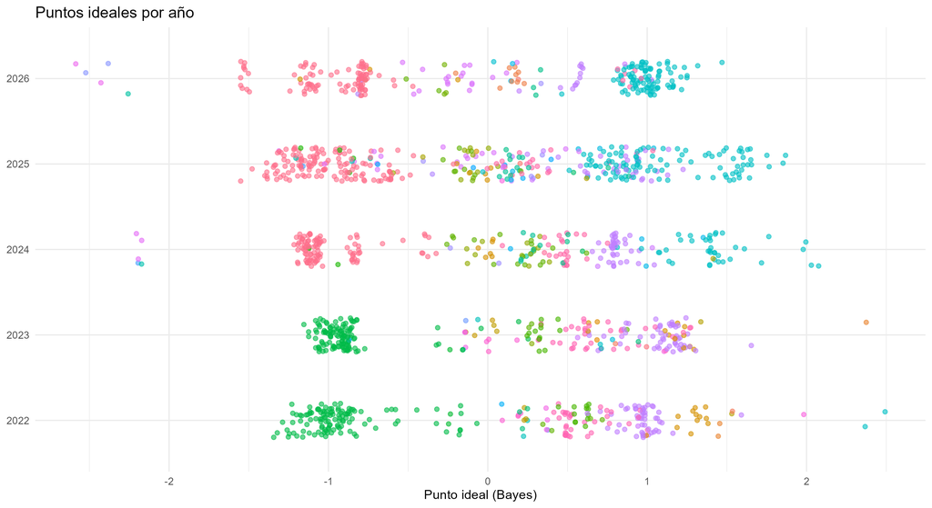

## Cohesión interna por bloque

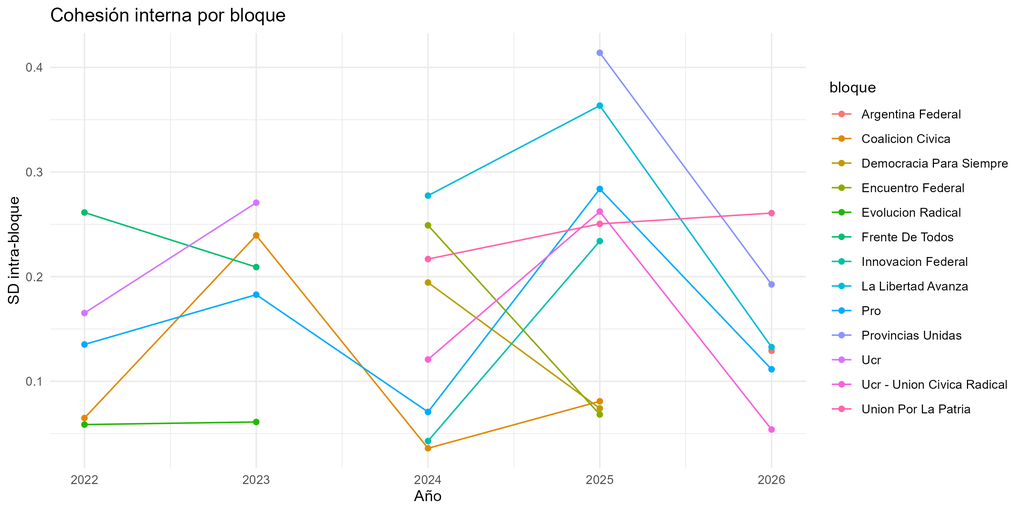

## Red de coincidencia 2024: comunidades vs. bloques

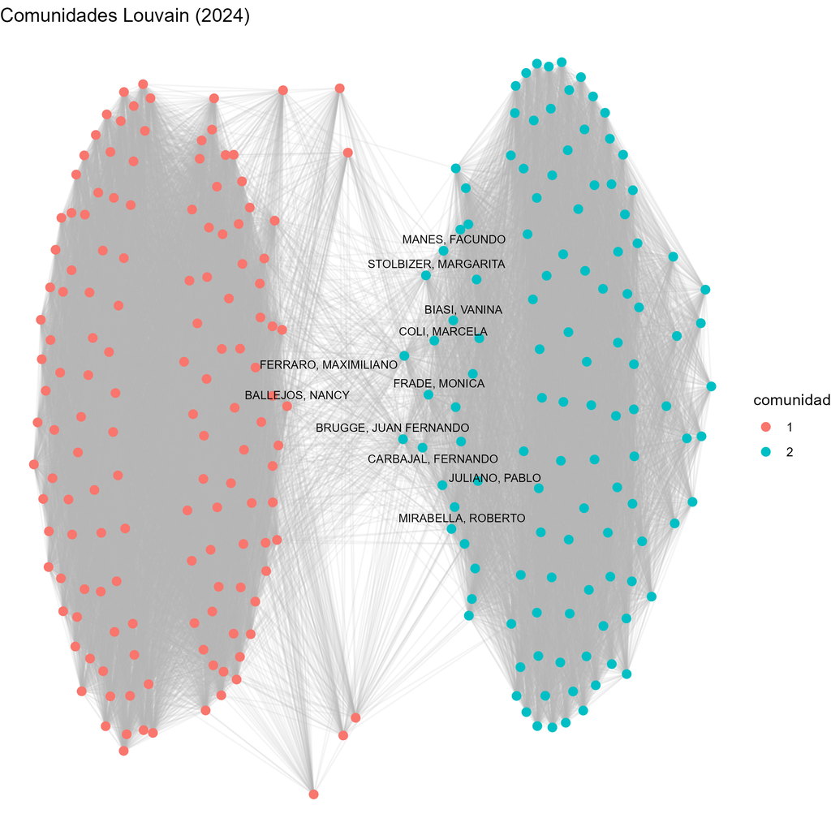

*Comunidades Louvain*

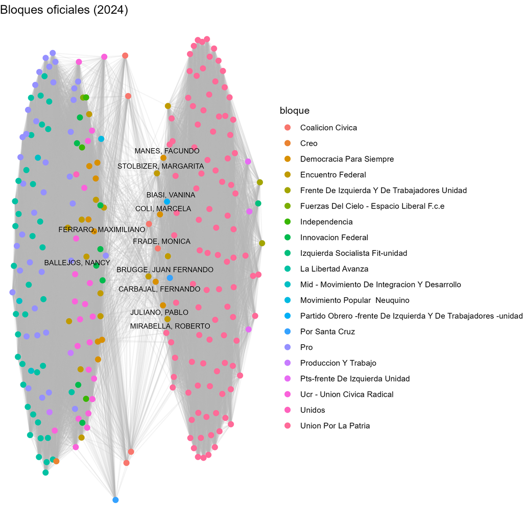

*Bloques oficiales*

## ¿La red reproduce los bloques?

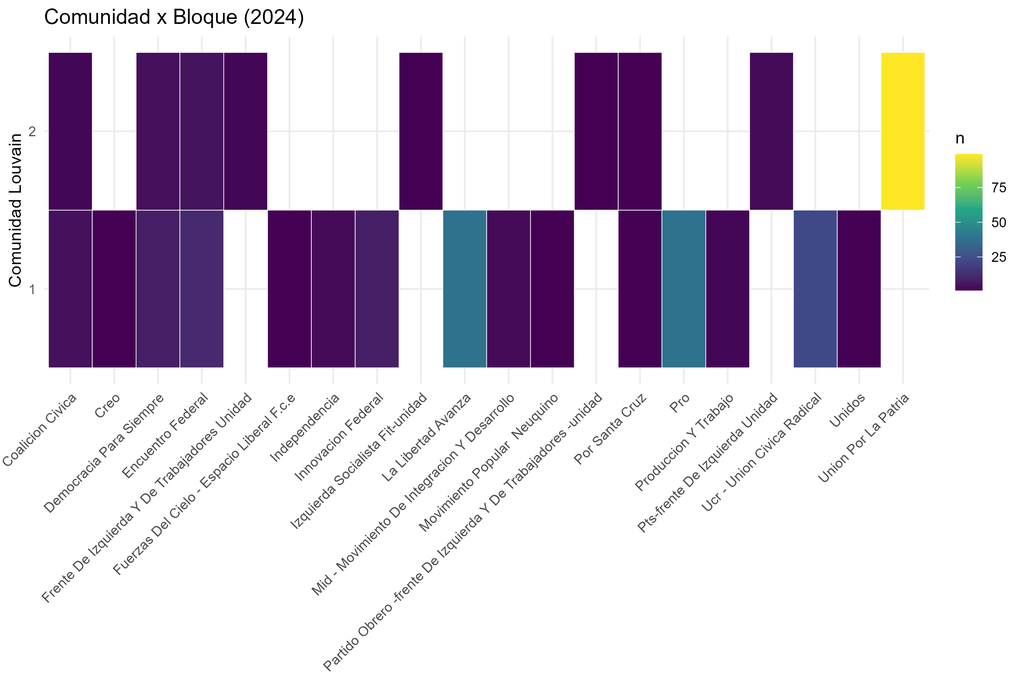

## Top puentes entre comunidades

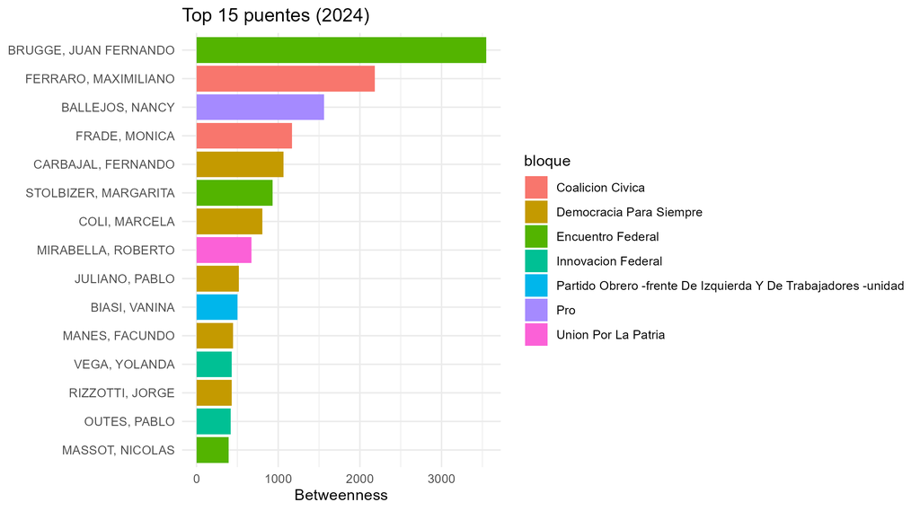

## Puentes vs. ubicación ideológica

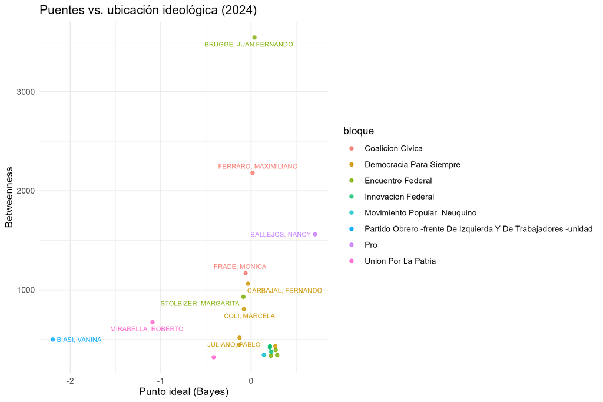

## Limitaciones

- El eje PCA cambia de escala entre años; se estandarizó por año pero no es perfectamente comparable.
- La `sd_bayes` alta indica legisladores poco identificados.
- La red mide **coincidencia**, no causalidad ni acuerdo político explícito.
- Louvain es estocástico: correr con semilla fija para reproducibilidad.

## Gracias

**¿Preguntas?**

[figure not shown]

## Code

[output not shown]